# Fundamentals of Data Visualization Solutions

R for the Rest of Us

The exercises are part of the Fundamentals of R course. For more, see the [R for the Rest of Us website](https://rfortherestofus.com/courses/fundamentals/).

# Load Packages

Let’s load the packages we need. These include `tidyverse` (especially the `dplyr` package) and `janitor`.

```r
library(tidyverse)
library(janitor)
```

# Import NHANES Data

Import your data into a data frame called NHANES. Use `clean_names` to make your variable names easy to work with.

```r
nhanes <- read_csv("data/nhanes.csv") %>%
  clean_names()
```

# Scatterplot

Make a scatterplot that shows weight on the x axis and height on the y axis.

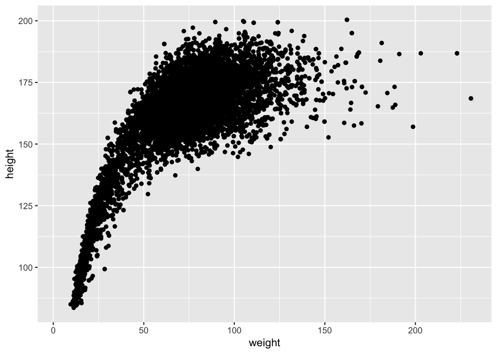

```r
ggplot(data = nhanes,
       mapping = aes(x = weight,
                     y = height)) +
  geom_point()
```

# Histogram

Make a histogram that shows the distribution of the weight variable.

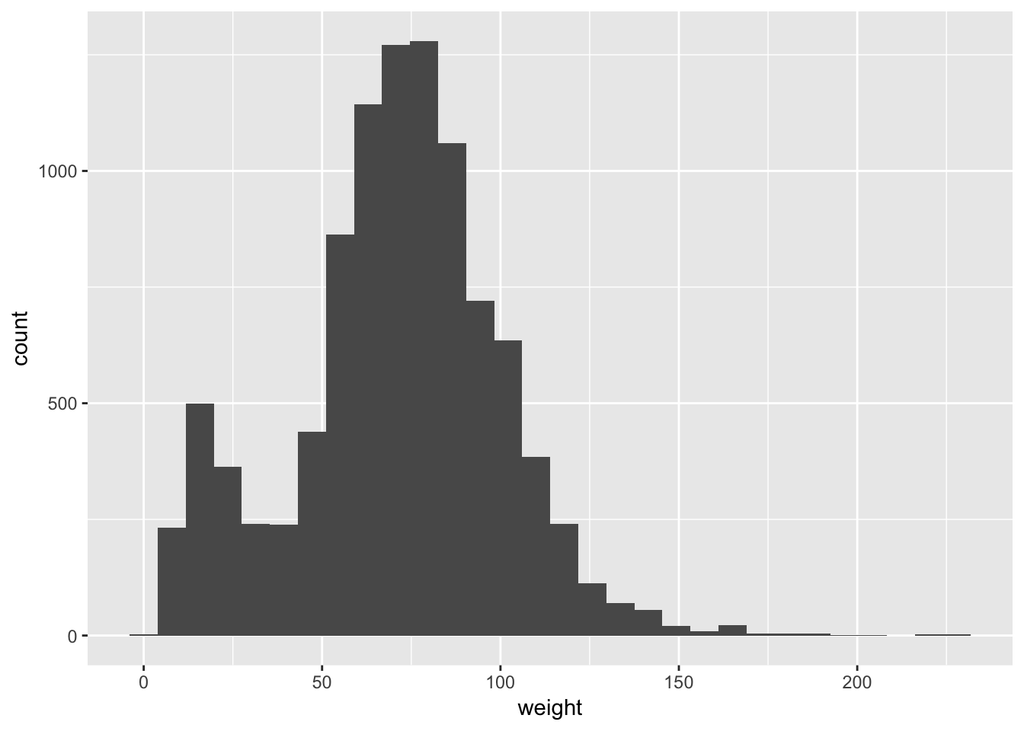

```r
ggplot(data = nhanes,
       mapping = aes(x = weight)) +
  geom_histogram()
```

Copy your code from above, but adjust it so that there are 50 bins.

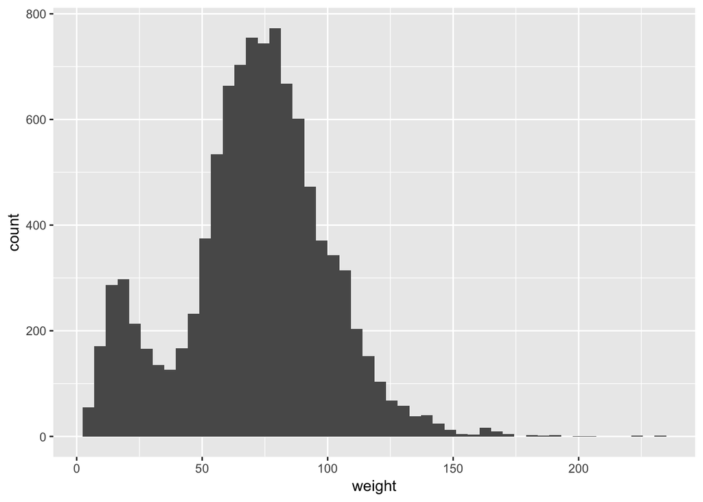

```r
ggplot(data = nhanes,
       mapping = aes(x = weight)) +
  geom_histogram(bins = 50)
```

# Bar Chart

## Bar Chart v1

Use the v1 approach to make a bar chart that shows a count of the number of people who say they smoke. Include NA responses.

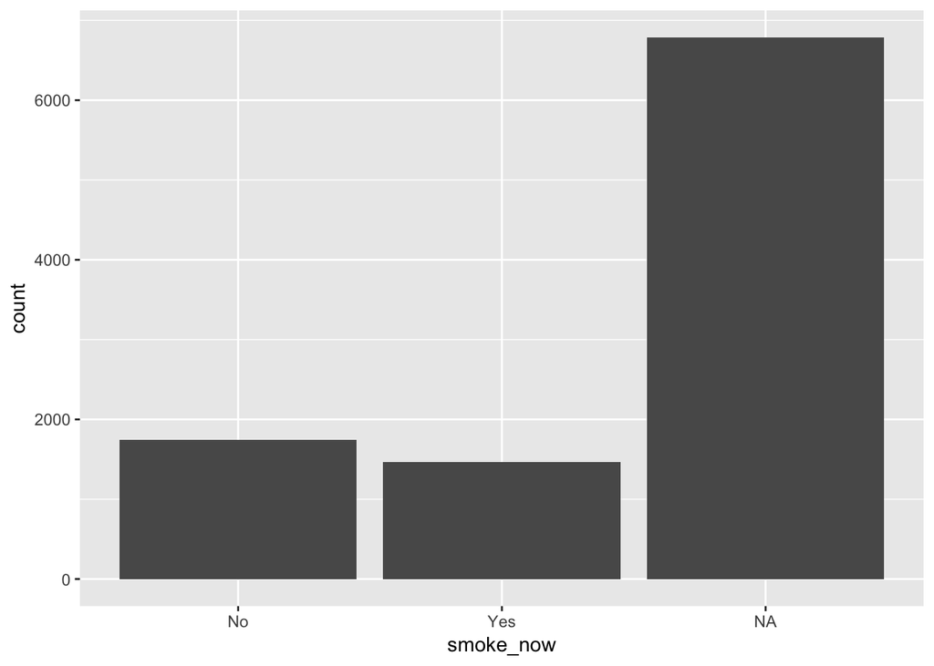

```r
ggplot(data = nhanes,
       mapping = aes(x = smoke_now)) +
  geom_bar()
```

## Bar Chart v2

Create a new data frame called `sleep_by_gender` that shows the average amount of sleep per night that males and females report getting. Drop any NA (or NaN) responses from this data frame.

```r
sleep_by_gender <- nhanes %>%
  group_by(gender) %>%
  summarize(avg_sleep = mean(sleep_hrs_night, na.rm = TRUE))
```

Plot the average amount of sleep per night for males and females.

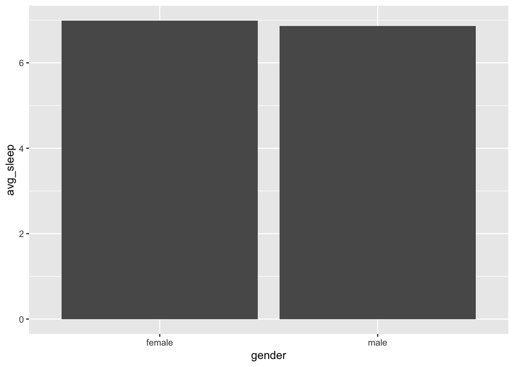

```r
ggplot(data = sleep_by_gender,
       mapping = aes(x = gender,
                     y = avg_sleep)) +
  geom_bar(stat = "identity")
```

Make the same graph as above, but use `geom_col` instead of `geom_bar`.

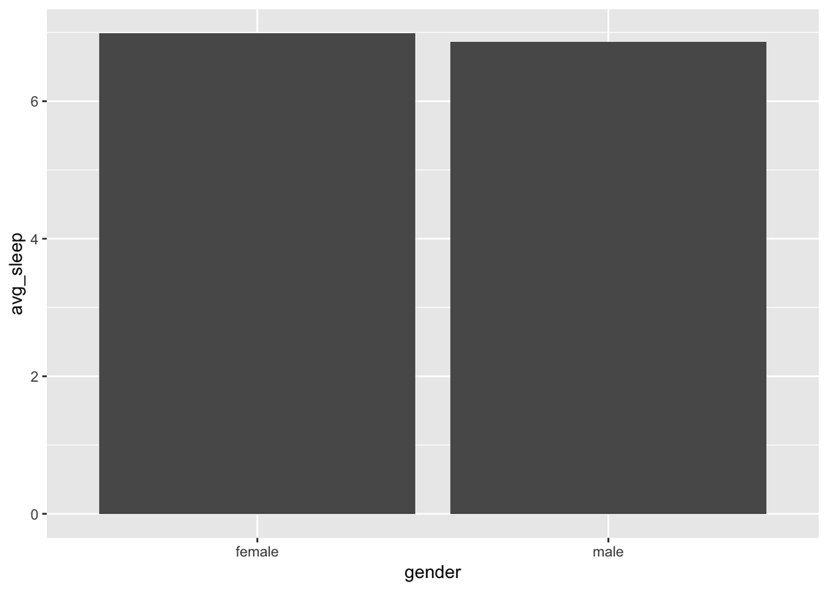

```r
ggplot(data = sleep_by_gender,
       mapping = aes(x = gender,
                     y = avg_sleep)) +
  geom_col()
```

# `color` and `fill`

Take your graph from above (the one with `geom_col`) and make the inside of each bar a different color.

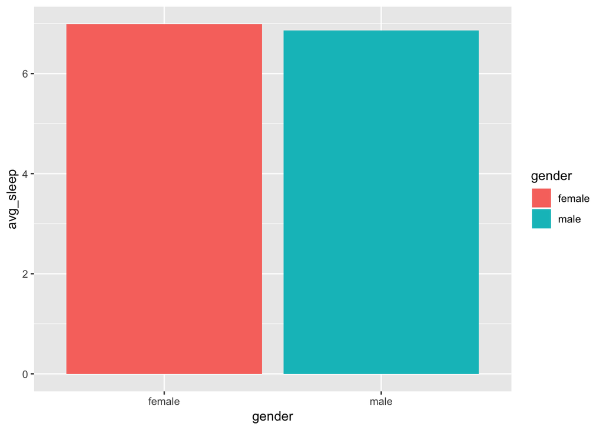

```r
ggplot(data = sleep_by_gender,
       mapping = aes(x = gender,
                     y = avg_sleep,
                     fill = gender)) +
  geom_col()
```

Make your scatterplot from before that shows weight on the x axis and height on the y axis again, but make the dots show up in different colors based on the `phys_active` variable.

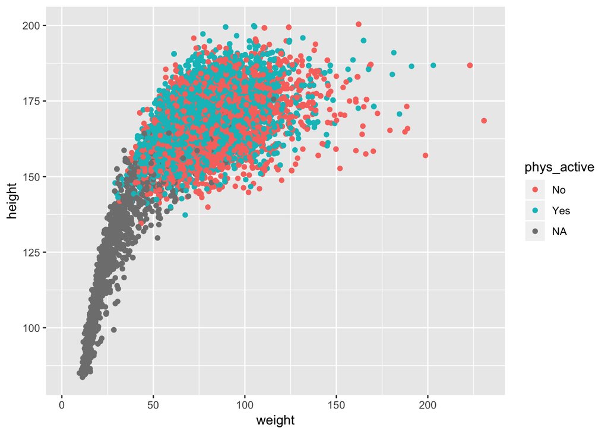

```r
ggplot(data = nhanes,
       mapping = aes(x = weight,
                     y = height,
                     color = phys_active)) +
  geom_point()
```

# Scales

## color

Take your scatterplot that you just made and add a scale using `scale_color_brewer`. Take a look at the help docs and choose a palette other than the default (hint: look at the `palette` argument).

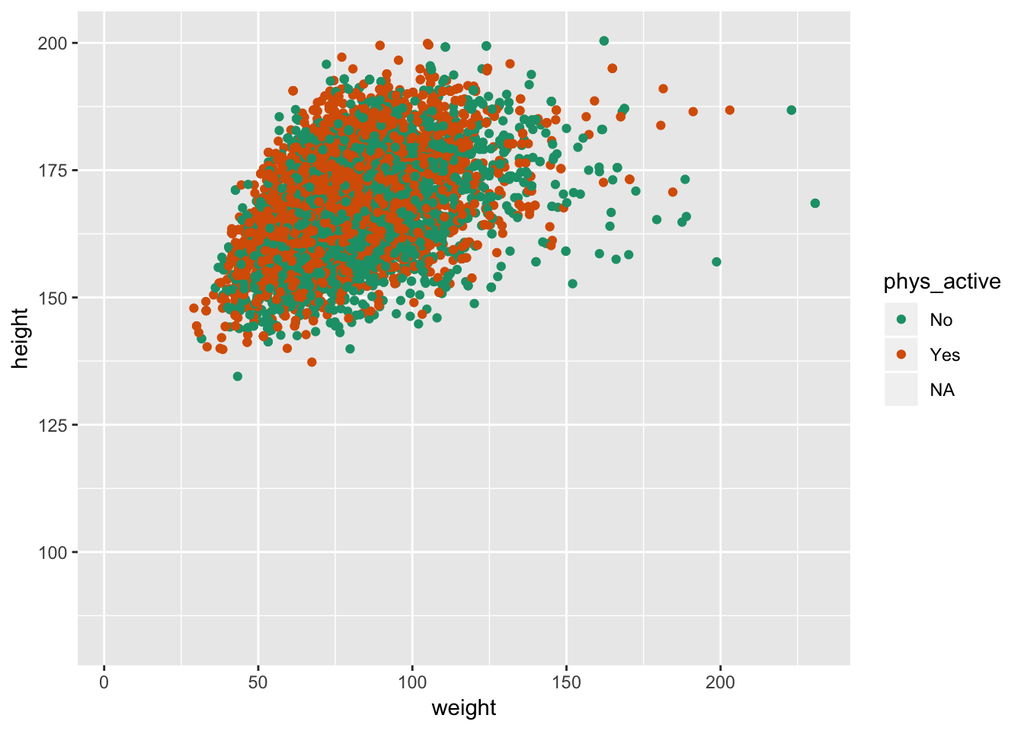

```r
ggplot(data = nhanes,
       mapping = aes(x = weight,
                     y = height,
                     color = phys_active)) +
  geom_point() +
  scale_color_brewer(palette = "Dark2")
```

Do nearly the same thing to change the color of the last bar chart you made (the one about sleep and gender).

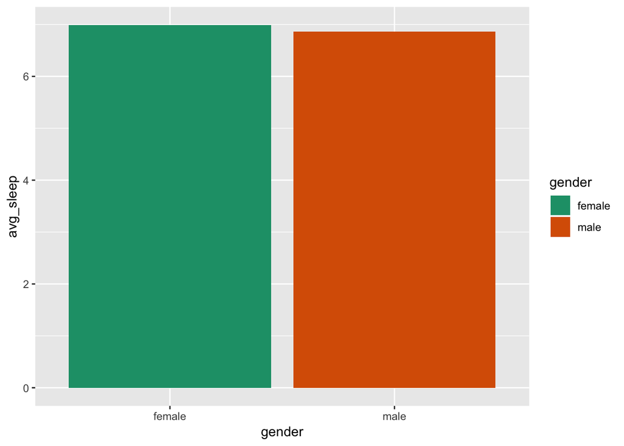

```r
ggplot(data = sleep_by_gender,
       mapping = aes(x = gender,
                     y = avg_sleep,
                     fill = gender)) +
  geom_col() +
  scale_fill_brewer(palette = "Dark2")
```

## x and y axes

Copy the graph you just made and change the y axis so it goes from 0 to 8.

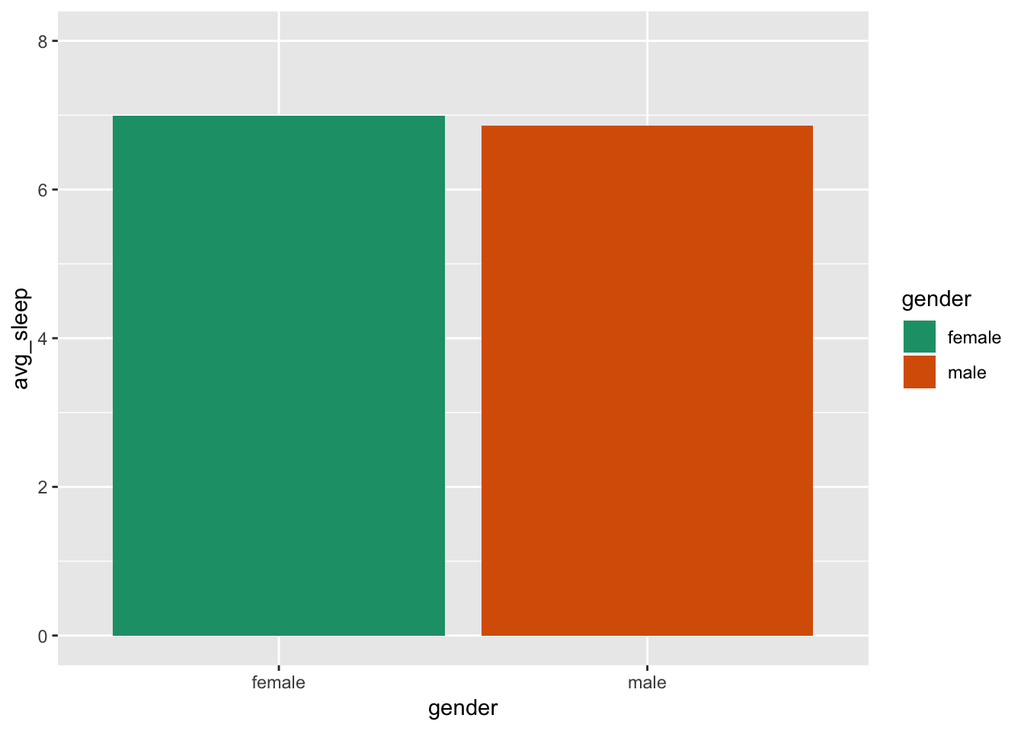

```r
ggplot(data = sleep_by_gender,
       mapping = aes(x = gender,
                     y = avg_sleep,
                     fill = gender)) +
  geom_col() +
  scale_fill_brewer(palette = "Dark2") +
  scale_y_continuous(limits = c(0, 8))
```

Copy the last code chunk. Then adjust the breaks on the y axis so that it shows 0 to 8 by 1 (i.e. 0, 1, 2, etc).

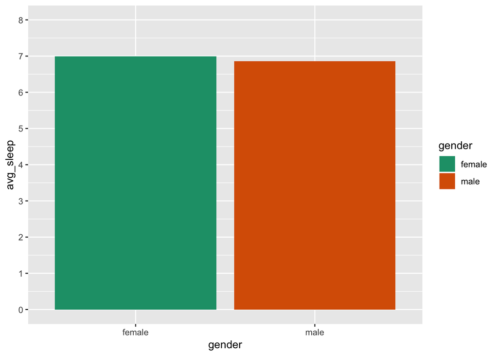

```r
ggplot(data = sleep_by_gender,
       mapping = aes(x = gender,
                     y = avg_sleep,
                     fill = gender)) +
  geom_col() +
  scale_fill_brewer(palette = "Dark2") +
  scale_y_continuous(limits = c(0, 8),
                     breaks = c(0, 1, 2, 3, 4, 5, 6, 7, 8))
```

# Text and Labels

Copy your last code chunk. Then do the following:

1. Add text labels to each bar.
2. Use the `round` argument to just show one decimal place in each label.
3. Use the `vjust` argument to have them show up at the inner edge of the bars.
4. Make the labels all white.

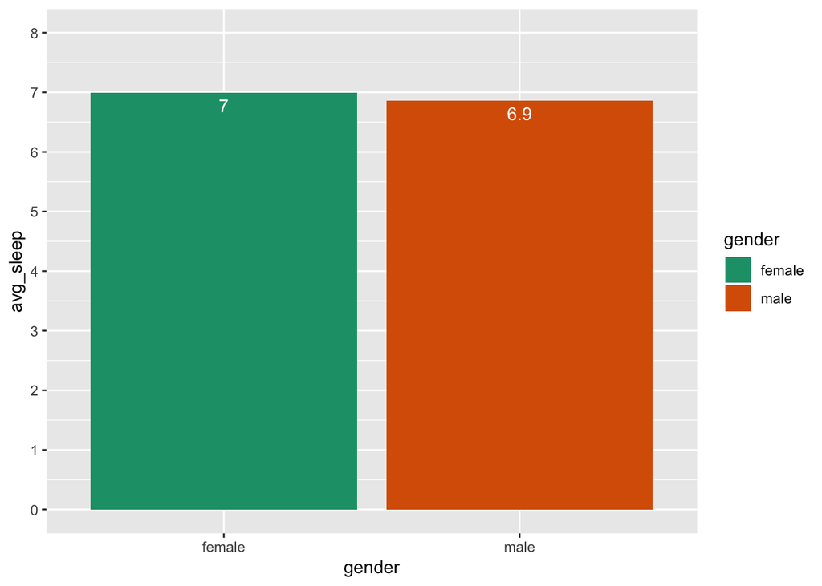

```r
ggplot(data = sleep_by_gender,
       mapping = aes(x = gender,
                     y = avg_sleep,
                     fill = gender)) +
  geom_col() +
  geom_text(aes(label = round(avg_sleep, 1)),
            vjust = 1.5,
            color = "white") +
  scale_fill_brewer(palette = "Dark2",
                    na.value = "blue") +
  scale_y_continuous(limits = c(0, 8),
                     breaks = c(0, 1, 2, 3, 4, 5, 6, 7, 8))
```

Do the same thing as above, but use `geom_label` instead of `geom_text`. Also, do the following:

1. Use the `vjust` argument to have them show up at the outer edge of the bars.
2. Don’t show the legend (hint: you’ll have to add code in two places to make this happen).

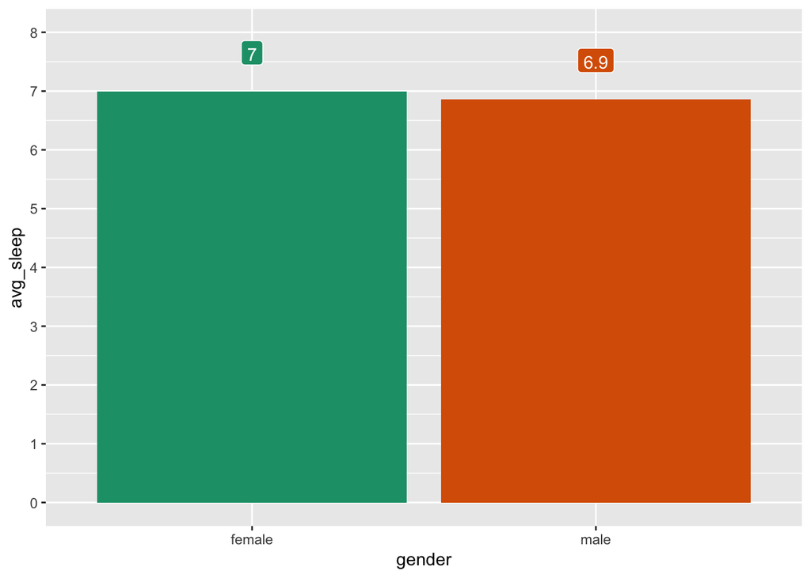

```r
ggplot(data = sleep_by_gender,
       mapping = aes(x = gender,
                     y = avg_sleep,
                     fill = gender)) +
  geom_col(show.legend = FALSE) +
  geom_label(aes(label = round(avg_sleep, 1)),
            vjust = -1.1,
            show.legend = FALSE,
            color = "white") +
  scale_fill_brewer(palette = "Dark2",
                    na.value = "blue") +
  scale_y_continuous(limits = c(0, 8),
                     breaks = c(0, 1, 2, 3, 4, 5, 6, 7, 8))
```

# Plot Labels

Use the code chunk from above with `geom_text` (not the last one with `geom_label`). Do the following:

1. Add a title
2. Add a better y axis label
3. Remove the x axis label
4. Remove the legend (hint: use the `show.legend` argument again)

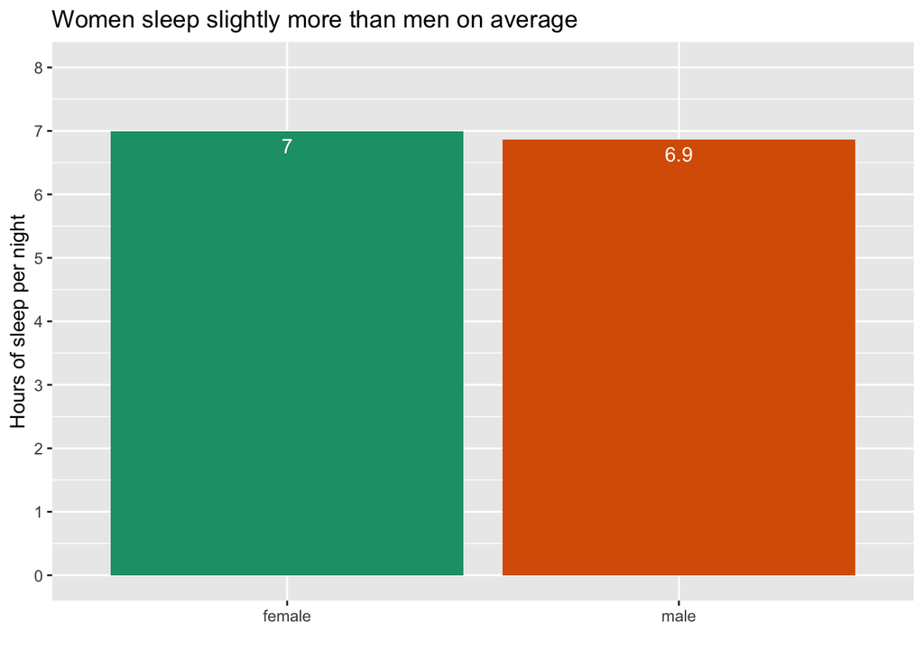

```r
ggplot(data = sleep_by_gender,
       mapping = aes(x = gender,
                     y = avg_sleep,
                     fill = gender)) +
  geom_col(show.legend = FALSE) +
  geom_text(aes(label = round(avg_sleep, 1)),
            vjust = 1.5,
            color = "white") +
  scale_fill_brewer(palette = "Dark2",
                    na.value = "blue") +
  scale_y_continuous(limits = c(0, 8),
                     breaks = c(0, 1, 2, 3, 4, 5, 6, 7, 8)) +
  labs(title = "Women sleep slightly more than men on average",
       y = "Hours of sleep per night",
       x = "")
```

# Themes

Install and load the [`hrbrthemes` package](https://hrbrmstr.github.io/hrbrthemes/index.html). It’s a package that provides some great default themes.

It’s not available on CRAN, where we normally install packages from, which means you have to install it slightly differently. You’ll use the `devtools` package and then use this to install the `hrbrthemes` package. Use the code below.

```r
# install.packages("devtools")
# devtools::install_github("hrbrmstr/hrbrthemes")
library(hrbrthemes)
```

Then add the `theme_ipsum` to your plot.

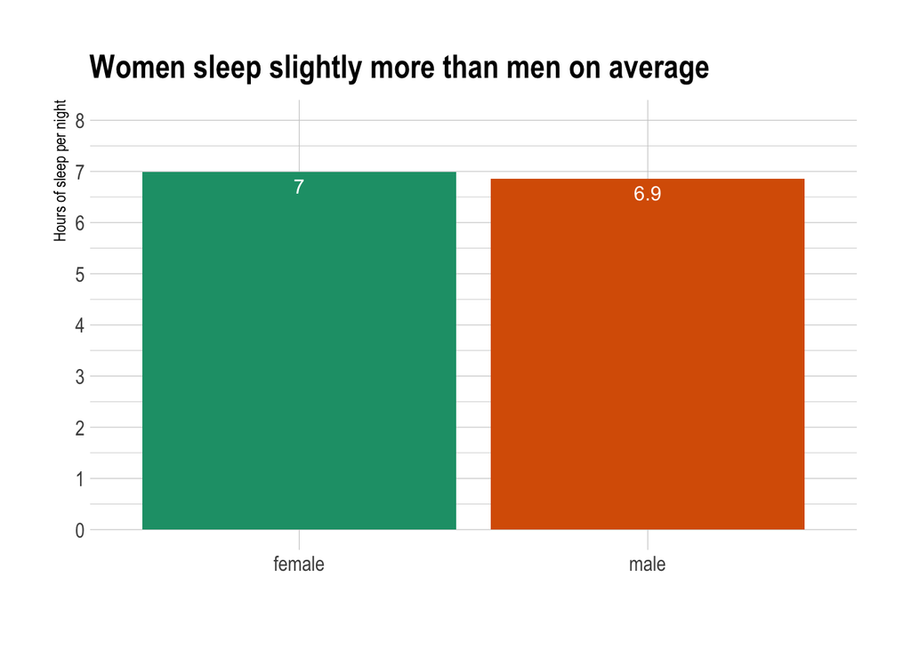

```r
ggplot(data = sleep_by_gender,
       mapping = aes(x = gender,
                     y = avg_sleep,
                     fill = gender)) +
  geom_col(show.legend = FALSE) +
  geom_text(aes(label = round(avg_sleep, 1)),
            vjust = 1.5,
            color = "white") +
  scale_fill_brewer(palette = "Dark2",
                    na.value = "blue") +
  scale_y_continuous(limits = c(0, 8),
                     breaks = c(0, 1, 2, 3, 4, 5, 6, 7, 8)) +
  labs(title = "Women sleep slightly more than men on average",
       y = "Hours of sleep per night",
       x = "") +
  theme_ipsum()
```

# Facets

I’ve created a data frame called `sleep_by_gender_by_age` for you. Run the code chunk below to load the data frame.

```r
sleep_by_gender_by_age <- nhanes %>%
  group_by(gender, age_decade) %>%
  summarize(avg_sleep = mean(sleep_hrs_night, na.rm = TRUE)) %>%
  drop_na()
```

Let’s take a look at `sleep_by_gender_by_age`.

```r
sleep_by_gender_by_age
```

| gender | age_decade | avg_sleep |
| --- | --- | --- |
| female | 10-19 | 7.388889 |
| female | 20-29 | 6.979321 |
| female | 30-39 | 6.970458 |
| female | 40-49 | 6.829161 |
| female | 50-59 | 6.799353 |
| female | 60-69 | 7.039666 |
| female | 70+ | 7.129310 |
| male | 10-19 | 7.524345 |
| male | 20-29 | 6.918519 |
| male | 30-39 | 6.787557 |

[output cut: 4 more lines]

Now, see if you can recreate this plot. Much of the code will be the same from your previous plots using the `sleep_by_gender` data frame so just make some small changes.

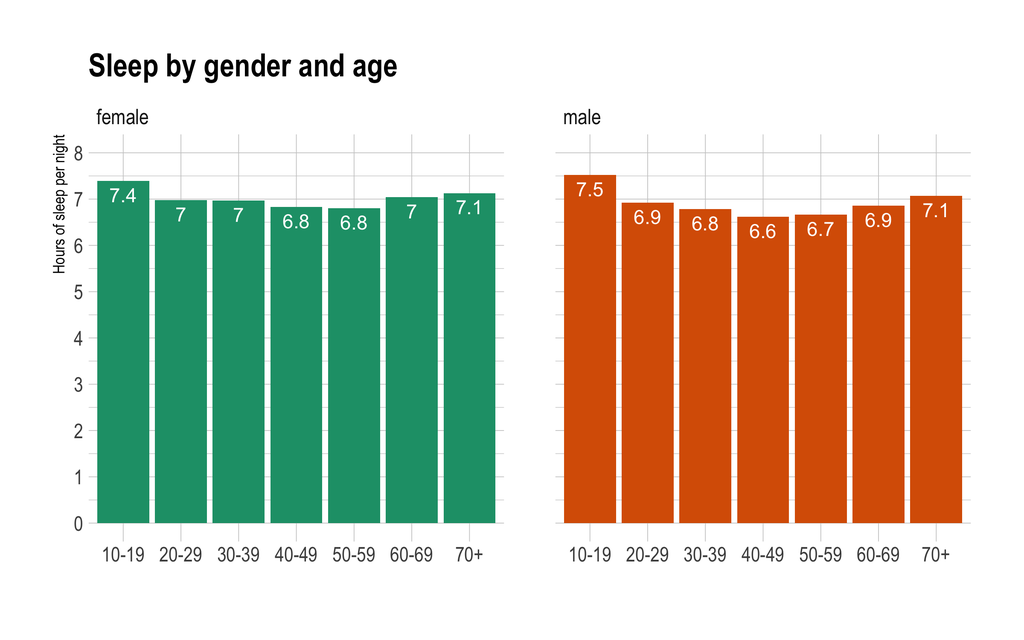

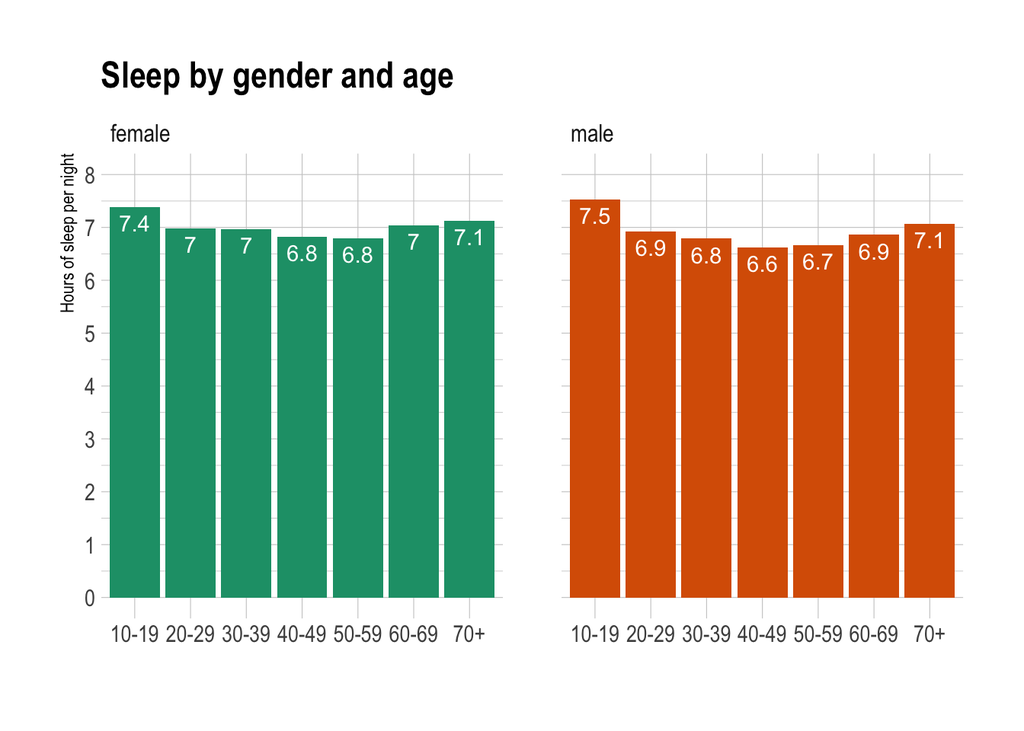

```r
ggplot(data = sleep_by_gender_by_age,
       aes(x = age_decade,
           y = avg_sleep,
           fill = gender)) +
  geom_col(show.legend = FALSE) +
  geom_text(aes(label = round(avg_sleep, 1)),
            vjust = 1.5,
            color = "white") +
  scale_y_continuous(limits = c(0, 8),
                     breaks = seq(0, 8, by = 1)) +
  scale_fill_brewer(palette = "Dark2") +
  facet_wrap(~gender) +
  theme_ipsum() +
  labs(title = "Sleep by gender and age",
       y = "Hours of sleep per night",
       x = "")
```

# Save Plots

Save your last plot to a PNG that is 8 inches wide and 5 inches high. Put it in the plots directory and call it “my-sleep-plot.png”

```r
ggsave(filename = "plots/my-sleep-plot.png",
       height = 5,
       width = 8,
       unit = "in")
```